# EE6310 - Image and Video Processing, HW6

```python
import matplotlib.pyplot as plt
import matplotlib.image as mpimg
import numpy as np
import cv2
```

## 1) Motion Estimation

In this problem you will implement the most critical part of the video codec – the motion estimator. Do the following:

### 1. Use the 3-step search to find motion vectors

- Use mean absolute distance (MAD) as your metric.
- Step 1: Search at 8 location ±4 pixels around current macroblock including (0, 0) (relative to current macroblock).
- Step 2: search at 8 location ±2 pixels around best match location in Step 1 including best match location.
- Step 3: search at 8 location ±1 pixels around best match location in Step 2 including best match location.

```
First Frame
(144, 176)
```

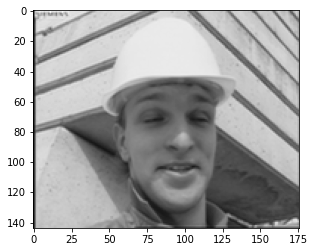

```python
print("First Frame")
img1 = mpimg.imread("first_frame.png")
print(np.shape(img1))
imgplot_1 = plt.imshow(img1, cmap=plt.cm.gray)
```

```
Second Frame
```

[figure not shown]

```python
print("Second Frame")
img2 = mpimg.imread("second_frame.png")
imgplot_2 = plt.imshow(img2, cmap=plt.cm.gray)
```

```python
rows, cols = np.shape(img1)
for i in range(rows):
    for j in range(cols):
        img1[i][j] = img1[i][j] * 255
rows, cols = np.shape(img2)
for i in range(rows):
    for j in range(cols):
        img2[i][j] = img2[i][j] * 255
```

```python
def valid(i, j):
    if i < 0 or i > 128:
        return 0
    if j < 0 or j > 160:
        return 0
    return 1


def window1(i, j):
    temp = np.zeros((16, 16))
    if valid(i, j):
        temp = img2[i : i + 16, j : j + 16]
        return temp
    else:
        return temp


def window2(i, j):
    temp = np.zeros((16, 16))
    if valid(i, j):
        temp = img1[i : i + 16, j : j + 16]
        return temp
    else:
        return temp
```

```python
def select(i, j):
    arr1 = [
        [0, 0],
        [-4, 0],
        [4, 0],
        [-4, 4],
        [-4, -4],
        [4, 4],
        [4, -4],
        [0, 4],
        [0, -4],
    ]
    arr2 = [
        [0, 0],
        [-2, 0],
        [2, 0],
        [-2, 2],
        [-2, -2],
        [2, 2],
        [2, -2],
        [0, 2],
        [0, -2],
    ]
    arr3 = [
        [0, 0],
        [-1, 0],
        [1, 0],
        [-1, 1],
        [-1, -1],
        [1, 1],
        [1, -1],
        [0, 1],
        [0, -1],
    ]
    cur_arr = window1(i, j)
    min_index = None
    min_sum = None
    for f in arr1:
        if valid(i + f[0], j + f[1]):
            temp = window2(i + f[0], j + f[1])
            temp = np.subtract(cur_arr, temp)
            temp = abs(temp)
            s = sum(sum(temp))
        if min_sum == None or min_sum > s:
            min_sum = s
            min_index = [i + f[0], j + f[1]]
    temp1 = min_index[0]
    temp2 = min_index[1]
    min_index = None
    min_sum = None
    for se in arr2:
        if valid(temp1 + se[0], temp2 + se[1]):
            temp = window2(temp1 + se[0], temp2 + se[1])
            temp = np.subtract(cur_arr, temp)
            temp = abs(temp)
            s = sum(sum(temp))
        if min_sum == None or min_sum > s:
            min_sum = s
            min_index = [temp1 + se[0], temp2 + se[1]]
    temp1 = min_index[0]
    temp2 = min_index[1]
    min_index = None
    min_sum = None
    for t in arr3:
        if valid(temp1 + t[0], temp2 + t[1]):
            temp = window2(temp1 + t[0], temp2 + t[1])
            temp = np.subtract(cur_arr, temp)
            temp = abs(temp)
            s = sum(sum(temp))
        if min_sum == None or min_sum > s:
            min_sum = s
            min_index = [temp1 + t[0], temp2 + t[1]]
    return min_index[0], min_index[1]
```

```python
motion_vectors = [[0 for i in range(11)] for j in range(9)]
indices = [[0 for i in range(11)] for j in range(9)]
rows, cols = np.shape(img2)
for i in range(0, rows, 16):
    for j in range(0, cols, 16):
        motion_vectors[int(i / 16)][int(j / 16)] = select(i, j)
        indices[int(i / 16)][int(j / 16)] = i, j
```

### 2. Plot the motion vector at each macroblock.

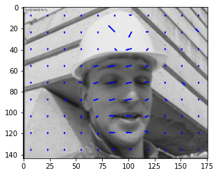

```python
imgplot_2 = plt.imshow(img2, cmap=plt.cm.gray)
rows, cols = np.shape(img2)
for i in range(0, rows, 16):
    for j in range(0, cols, 16):
        temp3, temp4 = np.subtract(motion_vectors, indices)[int(i / 16)][int(j / 16)]
        plt.arrow(j + 7, i + 7, temp4, temp3, head_width=1, width=0.5, ec="blue")
plt.show()
```

### 3. Generate the motion compensated predicted frame using the motion vectors and the first frame

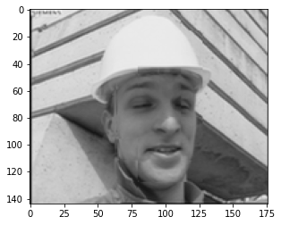

```python
pred_img = np.zeros((144, 176))
rows, cols = np.shape(img1)
for i in range(0, rows, 16):
    for j in range(0, cols, 16):
        temp5, temp6 = motion_vectors[int(i / 16)][int(j / 16)]
        pred_img[i : i + 16, j : j + 16] = img1[temp5 : temp5 + 16, temp6 : temp6 + 16]
imgplot_3 = plt.imshow(pred_img, cmap=plt.cm.gray)
```

### Compute the error between the second frame and its motion compensated predicted version and display it

Instructions:

- Do not use built-in functions.
- Divide each frame into non-overlapping macroblocks of size 16×16 pixels. Note that the images are of size 176 × 144.
- Generate motion vectors at each macroblock in the second frame from the first.

```
2.956912878787879
```

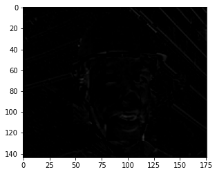

```python
diff_img = np.subtract(pred_img, img2)
print(sum(sum(abs(diff_img))) / (rows * cols))
imgplot_3 = plt.imshow(diff_img, cmap=plt.cm.gray, vmin=0, vmax=255)
```

## 2) SSIM index

Write a program to implement the SSIM index. Your program should also display the SSIM map. Generate test images by adding noise, blurring and compressing the reference image (all separately)

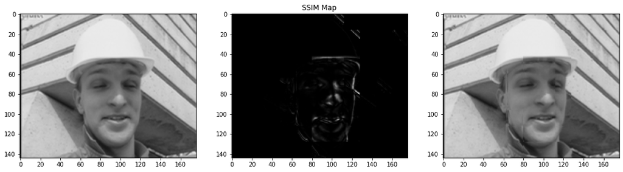

```python
def display_SSIM_map(img1, img2, ssim_map):
    fig, ax = plt.subplots(1, 3)
    fig.set_size_inches(18, 5)
    ax[0].imshow(img1, cmap=plt.cm.gray)
    ax[1].imshow(ssim_map, cmap=plt.cm.gray)
    ax[1].set_title("SSIM Map")
    ax[2].imshow(img2, cmap=plt.cm.gray)
    plt.show()


def SSIM_map(img1, img2):
    ssim_map = np.zeros(img1.shape)
    for i in range(img1.shape[0]):
        for j in range(img1.shape[1]):
            ssim_map[i, j] = np.sum(np.square(img1[i, j] - img2[i, j]))
    display_SSIM_map(img1, img2, ssim_map)


SSIM_map(img1, pred_img)
```

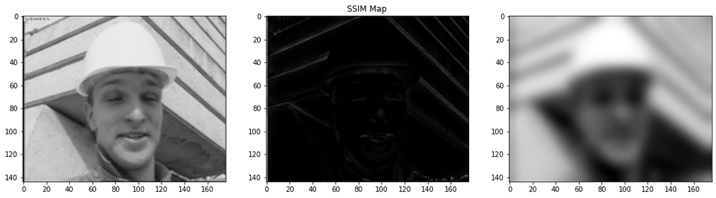

```python
def blur_img(img, sigma):
    img = np.float32(img)
    img = cv2.GaussianBlur(img, (0, 0), sigma)
    return img


SSIM_map(img1, blur_img(img1, 5))
```

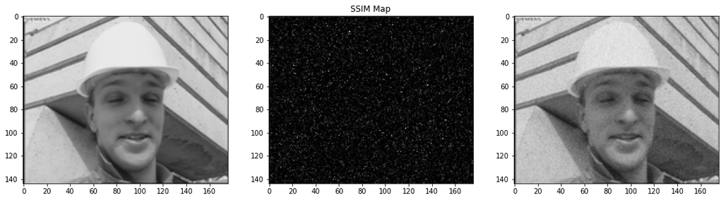

```python
def add_noise(img, sigma):
    img = np.float32(img)
    img = img + np.random.normal(0, sigma, img.shape)
    return img


SSIM_map(img1, add_noise(img1, 5))
```

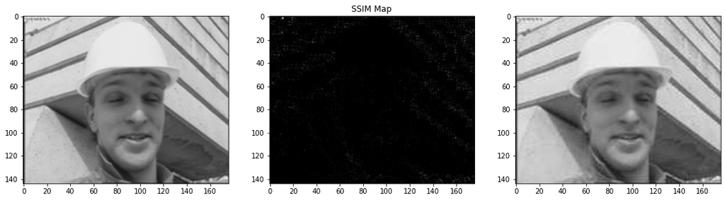

```python
def compress_img_jpg(img, quality, name):
    img = np.uint8(img)
    cv2.imwrite(f"{name}.jpg", img, [cv2.IMWRITE_JPEG_QUALITY, quality])


compress_img_jpg(img1, 50, "img1")

SSIM_map(img1, plt.imread("img1.jpg"))
```

## 3) Edge Detection

In this problem, you will write a program to compute the edge map of an image. See Remarks for image.

### 3.1 Gradient Edge Detectors

- Centered 2-D differencing.
- Roberts operator.
- Prewitt operator.
- Sobel operator.

### 3.2 Laplacian Edge Detectors

#### 3.2.1 Compute the Laplacian using the convolution template

```
[
    [0, 1, 0],
    [1, -4, 1],
    [0, 1, 0]
]
```

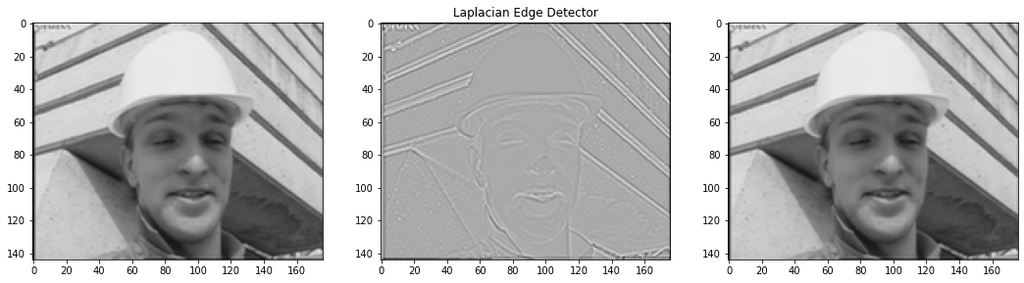

```python
def laplacian_edge_detector(img, conv_template):
    pad_size = conv_template.shape[0] // 2
    img_pad = np.pad(img, pad_size, mode="constant")
    img_conv = np.zeros_like(img)
    for i in range(img.shape[0]):
        for j in range(img.shape[1]):
            img_conv[i, j] = np.sum(
                img_pad[i : i + conv_template.shape[0], j : j + conv_template.shape[1]]
                * conv_template
            )
    return img_conv


conv_template = np.array([[0, 1, 0], [1, -4, 1], [0, 1, 0]])


def display_laplacian_edge_detector(img, conv_template):
    fig, ax = plt.subplots(1, 3)
    fig.set_size_inches(18, 5)
    ax[0].imshow(img, cmap=plt.cm.gray)
    ax[1].imshow(laplacian_edge_detector(img, conv_template), cmap=plt.cm.gray)
    ax[1].set_title("Laplacian Edge Detector")
    ax[2].imshow(img, cmap=plt.cm.gray)
    plt.show()


display_laplacian_edge_detector(img1, conv_template)
```

#### 3.2.2 Compute the edge map E as the output of a zero crossing detector.

[figure not shown]

```python
def edge_map_of_zero_crossing_detector(img):
    edge_map = np.zeros(img.shape)
    for i in range(1, img.shape[0] - 1):
        for j in range(1, img.shape[1] - 1):
            if img[i, j] > 0:
                if img[i - 1, j] < 0 and img[i + 1, j] < 0:
                    edge_map[i, j] = 1
                elif img[i, j - 1] < 0 and img[i, j + 1] < 0:
                    edge_map[i, j] = 1
    return edge_map


def display_edge_map_of_zero_crossing_detector(img):
    fig, ax = plt.subplots(1, 3)
    fig.set_size_inches(18, 5)
    ax[0].imshow(img, cmap=plt.cm.gray)
    ax[1].imshow(edge_map_of_zero_crossing_detector(img), cmap=plt.cm.gray)
    ax[1].set_title("Edge Map of Zero Crossing Detector")
    ax[2].imshow(img, cmap=plt.cm.gray)
    plt.show()


display_edge_map_of_zero_crossing_detector(img1)
```